# HAR-WLE

Monica Maria Solorzano Rodriguez

12/5/2020

## Human Activity Recongnition - Weight Lifthing Excercise, HAR-WLE

Human activity recognition utilizes sensors, smartphones or images to track physical activity of persons for purposes like energy monitoring and usage, mostly in the field of health care. Papers started being published in 2006 as per records of the Institute of Electrical and Electronics Engineers. If you now go to their website and search for these key words, you get 422 million documents you can have access to in this and other related websites. In order to process and evaluate the data generated by the devices, there are various machine learning techniques used, for example: decision trees, K-nearest neighbors, support vector machines, hidden Markov models, among others. The data set to be used in the present assignment belongs to the “Qualitative Activity Recognition of Weight Lifting Excercises” research paper by Velloso, E., Bulling, A., Gellersen, H., Ugulino, W. and Fuks, H. (Proceedings of the 4th International Conference, Stuttgart, Germany: ACM SIGCHI, 2013), which investigates “how well” unilateral dumbbell biceps curl is performed, see http://web.archive.org/web/20161224072740/http:/groupware.les.inf.puc-rio.br/har.

Six individuals perform a set of 10 repetitions of the said exercise in five different ways and classified accordingly, “A” means the exercise was done just as the specification requested, “B” denotes mistake in the elbow placement, “C” is mistake in the lifting distance, “D” mistake in the lowering distance, and “E” corresponds to mistake in posture of the individual. The sensors were located in the arm, forearm, dumbbell and belt, hence there are various measurements that were taken by the accelerometer, magnetometer and gyroscope. Let’s take a look at some features of the data set, it can be seen that some features are easily correlated whereas some others definitely not. The plot shows avg_roll_belt, var_roll_belt, var_accel_arm, magnet_arm_x, y and z, total_accel_dumbbell, gyros_dumbbell_x, y and z, magnet_dumbbell_x, y and z:

[figure not shown]

Taking a close look to all the variables, it can be seen that there are 33 variables that are in mode = character and which cannot be processed:

```
'data.frame':   19605 obs. of  33 variables:
 $ kurtosis_roll_belt     : chr  "" "" "" "" ...
 $ kurtosis_picth_belt    : chr  "" "" "" "" ...
 $ kurtosis_yaw_belt      : chr  "" "" "" "" ...
 $ skewness_roll_belt     : chr  "" "" "" "" ...
 $ skewness_roll_belt.1   : chr  "" "" "" "" ...
 $ skewness_yaw_belt      : chr  "" "" "" "" ...
 $ max_yaw_belt           : chr  "" "" "" "" ...
 $ min_yaw_belt           : chr  "" "" "" "" ...
 $ amplitude_yaw_belt     : chr  "" "" "" "" ...
 $ kurtosis_roll_arm      : chr  "" "" "" "" ...
 $ kurtosis_picth_arm     : chr  "" "" "" "" ...
 $ kurtosis_yaw_arm       : chr  "" "" "" "" ...
 $ skewness_roll_arm      : chr  "" "" "" "" ...
 $ skewness_pitch_arm     : chr  "" "" "" "" ...
```

[output cut: 19 more lines]

There are also 67 variables that have over 97% of NAs in them. Therefore, it was necessary to preform some data cleaning. Have a look:

```
         X0
141 97.9393
142 97.9393
143 97.9393
144 97.9393
145 97.9393
146 97.9393
147 97.9393
148 97.9393
149 97.9393
150 97.9393
151  0.0000
152  0.0000
153  0.0000
154  0.0000
155  0.0000
156  0.0000
157  0.0000
158  0.0000
159  0.0000
160  0.0000
```

```
 [1]   7   8   9  10  11  37  38  39  40  41  42  43  44  45  46  47  48  49  60
[20]  61  62  63  64  65  66  67  68  84  85  86 102 113 114 115 116 117 118 119
[39] 120 121 122 123 124 140 151 152 153 154 155 156 157 158 159
```

```
Random Forest

19605 samples
   53 predictor
    5 classes: 'A', 'B', 'C', 'D', 'E'

No pre-processing
Resampling: Cross-Validated (8 fold)
Summary of sample sizes: 17156, 17155, 17154, 17156, 17154, 17153, ...
Resampling results across tuning parameters:

  mtry  Accuracy   Kappa
   2    0.9965312  0.9956122
  27    0.9985206  0.9981287
  53    0.9962768  0.9952905

Accuracy was used to select the optimal model using the largest value.
The final value used for the model was mtry = 27.
```

```
   Accuracy     Kappa Resample
1 0.9983673 0.9979347    Fold2
2 0.9975500 0.9969013    Fold1
3 0.9979584 0.9974178    Fold4
4 0.9983680 0.9979357    Fold3
5 0.9991843 0.9989683    Fold6
6 0.9987760 0.9984518    Fold5
7 0.9987760 0.9984518    Fold8
8 0.9991843 0.9989683    Fold7
```

```
Cross-Validated (8 fold) Confusion Matrix

(entries are percentual average cell counts across resamples)

          Reference
Prediction    A    B    C    D    E
         A 28.4  0.0  0.0  0.0  0.0
         B  0.0 19.3  0.0  0.0  0.0
         C  0.0  0.0 17.4  0.0  0.0
         D  0.0  0.0  0.0 16.3  0.0
         E  0.0  0.0  0.0  0.0 18.4

 Accuracy (average) : 0.9985
```

The model was tested on the validation set partitioned right after reading the files and since it only has 17 observations to try to resemble the testing set, they all predicted successfully, accuracy 17/17. See here the plot of two variables from the validation set and an indicator of whether the prediction was correct or incorrect, showing that all predictions were accurately classified.

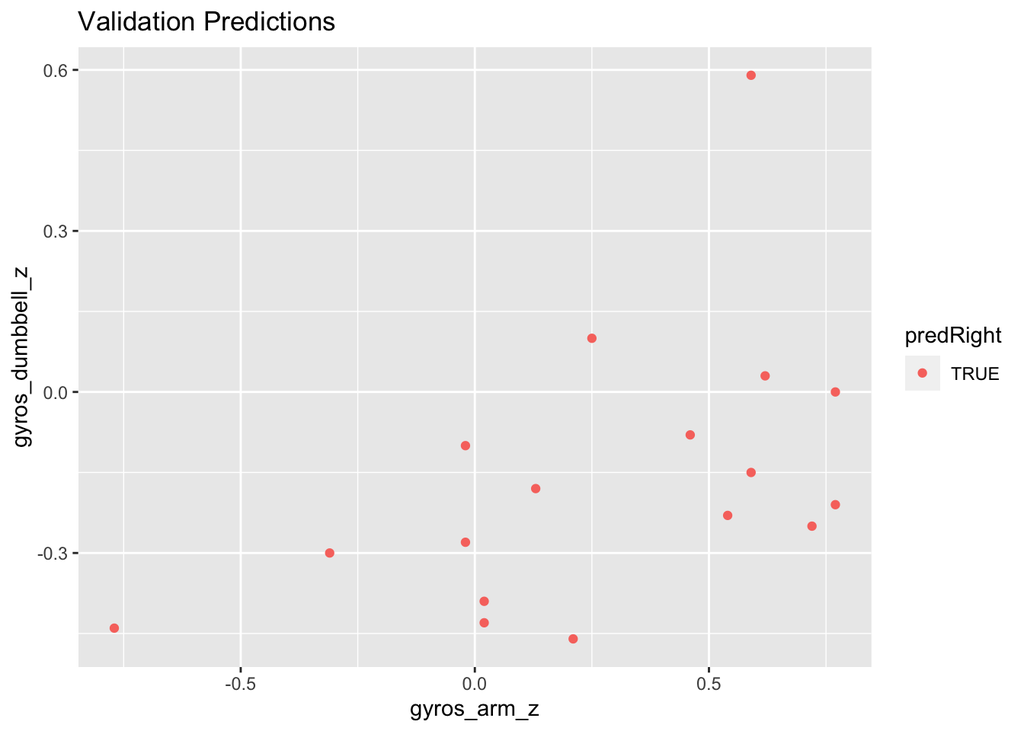

## CODE

```r
library(caret)
library(doParallel)
library(parallel)
library(dplyr)
library(snow)
TRurl <- "https://d396qusza40orc.cloudfront.net/predmachlearn/pml-training.csv"
TEurl <- "https://d396qusza40orc.cloudfront.net/predmachlearn/pml-testing.csv"
download.file(TRurl, destfile = "./pml-training.csv", method = "curl")
download.file(TEurl, destfile = "./pml-testing.csv", method = "curl")
training <- read.csv("./pml-training.csv", header = TRUE, sep = ",")
testing <- read.csv("./pml-testing.csv", header = TRUE, sep = ",")

#validation set
set.seed(54321)
inTraining <- createDataPartition(training$classe, p = 0.999, list = FALSE)
training2 <- training[inTraining, ]
validation <- training[-inTraining, ]

#feature plot
featurePlot(x = training2[, c(28, 30, 50, 66, 67, 68, 102, 113, 114, 115, 119, 120, 121)], y = factor(training2$classe), plot = "pairs")

#cleaning data
#columns with mode character in training[,  c(12:17, 20, 23, 26, 69:74, 87:92, 95, 98,101, 125:130, 133, 136, 139)]
str(training2)

#finding NA columns in train and selecting non NA columns --- object doesn't work
mn <- data.frame()
for (i in 1:160) {
  cm = mean(training2[, i])
  mn <- rbind(mn, cm)
}
n <- 1:160
mnn <- cbind(mn, n)

na98 <- data.frame()
for (i in 1:160) {
  tr = table(is.na(training2[, i]))
  na98 <- rbind(na98, tr)
}

NApercent <- data.frame()
for (i in 1:160) {
  NAp <- (1 - na98[i, 1]/length(training2$X)) * 100
  NApercent <- rbind(NApercent, NAp)
}
# columns with 97.89% of NAs that cannot be used as regressors are: training[, c(18:19, 21:22, 24:25, 27:36, 50:59, 75:83, 93:94, 96:97, 99:100, 103:112, 131:132, 134:135, 137:138, 141:150)]

nNAc <- filter(mnn, !is.na(mnn[, 1]))
co <- nNAc[, 2]
predictors <- co[4:56]
# columns without NAs that can be used as regressors: training[, c(1, 3, 4, 7,  8, 9, 10, 11, 37, 38, 39, 40, 41, 42, 43, 44, 45, 46, 47, 48, 49, 60, 61, 62, 63, 64, 65, 66, 67, 68, 84, 85, 86, 102, 113, 114, 115, 116, 117, 118, 119, 120, 121, 122, 123, 124, 140, 151, 152, 153, 154, 155, 156, 157, 158, 159)]
# Note that the first three will not be used as they are row numbers and dates (this is not a forecast).
y = training2[, 160]
x = training2[, c(7, 8, 9, 10, 11, 37, 38, 39, 40, 41, 42, 43, 44, 45, 46, 47, 48, 49, 60, 61, 62, 63, 64, 65, 66, 67, 68, 84, 85, 86, 102, 113, 114, 115, 116, 117, 118, 119, 120, 121, 122, 123, 124, 140, 151, 152, 153, 154, 155, 156, 157, 158, 159)]

# training
cluster <- makeCluster(detectCores() - 1)
registerDoParallel(cluster)
set.seed(12345)
fitControl <- trainControl(method = "cv", number = 8, allowParallel = TRUE, seeds = NULL)
fit <- train(x, y, method = "rf", data = training2, trControl = fitControl)
stopCluster(cluster)

fit
fit$resample
confusionMatrix.train(fit)

#validation
validation2 = validation[, c(7, 8, 9, 10, 11, 37, 38, 39, 40, 41, 42, 43, 44, 45, 46, 47, 48, 49, 60, 61, 62, 63, 64, 65, 66, 67, 68, 84, 85, 86, 102, 113, 114, 115, 116, 117, 118, 119, 120, 121, 122, 123, 124, 140, 151, 152, 153, 154, 155, 156, 157, 158, 159, 160)]

pred <- predict(fit, validation2)
pred
validation2$classe

# testing
testing2 = testing[, c(7, 8, 9, 10, 11, 37, 38, 39, 40, 41, 42, 43, 44, 45, 46, 47, 48, 49, 60, 61, 62, 63, 64, 65, 66, 67, 68, 84, 85, 86, 102, 113, 114, 115, 116, 117, 118, 119, 120, 121, 122, 123, 124, 140, 151, 152, 153, 154, 155, 156, 157, 158, 159, 160)]
```